# Risk Factor Analysis

## Outcome Variable

**Outcome Variable:** stunted

## Predictor Variables

**Intervention Variable:** hhwealth_quart

**Adjustment Set:**

- arm
- sex
- W_mage
- meducyrs
- feducyrs
- W_gagebrth
- W_birthwt
- W_birthlen
- W_nchldlt5
- W_parity
- delta_W_mage
- delta_meducyrs
- delta_feducyrs
- delta_W_gagebrth
- delta_W_birthwt
- delta_W_birthlen
- delta_W_nchldlt5
- delta_W_parity

## Stratifying Variables

The analysis was stratified on these variable(s):

- agecat
- studyid
- country

## Data Summary

| agecat | studyid | country | hhwealth_quart | stunted | n_cell | n |
| --- | --- | --- | --- | --- | --- | --- |
| Birth | ki0047075b-MAL-ED | BANGLADESH | Wealth Q4 | 0 | 51 | 213 |
| Birth | ki0047075b-MAL-ED | BANGLADESH | Wealth Q4 | 1 | 5 | 213 |
| Birth | ki0047075b-MAL-ED | BANGLADESH | Wealth Q1 | 0 | 41 | 213 |
| Birth | ki0047075b-MAL-ED | BANGLADESH | Wealth Q1 | 1 | 11 | 213 |
| Birth | ki0047075b-MAL-ED | BANGLADESH | Wealth Q2 | 0 | 39 | 213 |
| Birth | ki0047075b-MAL-ED | BANGLADESH | Wealth Q2 | 1 | 12 | 213 |
| Birth | ki0047075b-MAL-ED | BANGLADESH | Wealth Q3 | 0 | 45 | 213 |
| Birth | ki0047075b-MAL-ED | BANGLADESH | Wealth Q3 | 1 | 9 | 213 |
| Birth | ki0047075b-MAL-ED | BRAZIL | Wealth Q4 | 0 | 9 | 60 |
| Birth | ki0047075b-MAL-ED | BRAZIL | Wealth Q4 | 1 | 2 | 60 |
| Birth | ki0047075b-MAL-ED | BRAZIL | Wealth Q1 | 0 | 17 | 60 |
| Birth | ki0047075b-MAL-ED | BRAZIL | Wealth Q1 | 1 | 4 | 60 |
| Birth | ki0047075b-MAL-ED | BRAZIL | Wealth Q2 | 0 | 16 | 60 |
| Birth | ki0047075b-MAL-ED | BRAZIL | Wealth Q2 | 1 | 1 | 60 |
| Birth | ki0047075b-MAL-ED | BRAZIL | Wealth Q3 | 0 | 9 | 60 |
| Birth | ki0047075b-MAL-ED | BRAZIL | Wealth Q3 | 1 | 2 | 60 |
| Birth | ki0047075b-MAL-ED | INDIA | Wealth Q4 | 0 | 8 | 41 |
| Birth | ki0047075b-MAL-ED | INDIA | Wealth Q4 | 1 | 0 | 41 |
| Birth | ki0047075b-MAL-ED | INDIA | Wealth Q1 | 0 | 10 | 41 |
| Birth | ki0047075b-MAL-ED | INDIA | Wealth Q1 | 1 | 4 | 41 |
| Birth | ki0047075b-MAL-ED | INDIA | Wealth Q2 | 0 | 6 | 41 |
| Birth | ki0047075b-MAL-ED | INDIA | Wealth Q2 | 1 | 3 | 41 |
| Birth | ki0047075b-MAL-ED | INDIA | Wealth Q3 | 0 | 9 | 41 |
| Birth | ki0047075b-MAL-ED | INDIA | Wealth Q3 | 1 | 1 | 41 |
| Birth | ki0047075b-MAL-ED | NEPAL | Wealth Q4 | 0 | 6 | 26 |
| Birth | ki0047075b-MAL-ED | NEPAL | Wealth Q4 | 1 | 0 | 26 |
| Birth | ki0047075b-MAL-ED | NEPAL | Wealth Q1 | 0 | 8 | 26 |
| Birth | ki0047075b-MAL-ED | NEPAL | Wealth Q1 | 1 | 1 | 26 |
| Birth | ki0047075b-MAL-ED | NEPAL | Wealth Q2 | 0 | 2 | 26 |
| Birth | ki0047075b-MAL-ED | NEPAL | Wealth Q2 | 1 | 1 | 26 |

[output cut: 386 more lines]

The following strata were considered:

- agecat: 24 months, studyid: ki0047075b-MAL-ED, country: BANGLADESH
- agecat: 24 months, studyid: ki0047075b-MAL-ED, country: BRAZIL
- agecat: 24 months, studyid: ki0047075b-MAL-ED, country: INDIA
- agecat: 24 months, studyid: ki0047075b-MAL-ED, country: NEPAL
- agecat: 24 months, studyid: ki0047075b-MAL-ED, country: PERU
- agecat: 24 months, studyid: ki0047075b-MAL-ED, country: SOUTH AFRICA
- agecat: 24 months, studyid: ki0047075b-MAL-ED, country: TANZANIA, UNITED REPUBLIC OF
- agecat: 24 months, studyid: ki1000108-CMC-V-BCS-2002, country: INDIA
- agecat: 24 months, studyid: ki1000108-IRC, country: INDIA
- agecat: 24 months, studyid: ki1017093b-PROVIDE, country: BANGLADESH
- agecat: 24 months, studyid: ki1066203-TanzaniaChild2, country: TANZANIA, UNITED REPUBLIC OF
- agecat: 24 months, studyid: ki1113344-GMS-Nepal, country: NEPAL
- agecat: 24 months, studyid: ki1114097-CONTENT, country: PERU
- agecat: 24 months, studyid: ki1135781-COHORTS, country: GUATEMALA
- agecat: 24 months, studyid: ki1135781-COHORTS, country: PHILIPPINES
- agecat: 24 months, studyid: ki1148112-LCNI-5, country: MALAWI
- agecat: 24 months, studyid: kiGH5241-JiVitA-3, country: BANGLADESH
- agecat: 24 months, studyid: kiGH5241-JiVitA-4, country: BANGLADESH
- agecat: 6 months, studyid: ki0047075b-MAL-ED, country: BANGLADESH
- agecat: 6 months, studyid: ki0047075b-MAL-ED, country: BRAZIL
- agecat: 6 months, studyid: ki0047075b-MAL-ED, country: INDIA
- agecat: 6 months, studyid: ki0047075b-MAL-ED, country: NEPAL
- agecat: 6 months, studyid: ki0047075b-MAL-ED, country: PERU
- agecat: 6 months, studyid: ki0047075b-MAL-ED, country: SOUTH AFRICA
- agecat: 6 months, studyid: ki0047075b-MAL-ED, country: TANZANIA, UNITED REPUBLIC OF
- agecat: 6 months, studyid: ki1000108-CMC-V-BCS-2002, country: INDIA
- agecat: 6 months, studyid: ki1000108-IRC, country: INDIA
- agecat: 6 months, studyid: ki1017093b-PROVIDE, country: BANGLADESH
- agecat: 6 months, studyid: ki1066203-TanzaniaChild2, country: TANZANIA, UNITED REPUBLIC OF
- agecat: 6 months, studyid: ki1113344-GMS-Nepal, country: NEPAL
- agecat: 6 months, studyid: ki1114097-CONTENT, country: PERU
- agecat: 6 months, studyid: ki1135781-COHORTS, country: GUATEMALA
- agecat: 6 months, studyid: ki1135781-COHORTS, country: PHILIPPINES
- agecat: 6 months, studyid: ki1148112-LCNI-5, country: MALAWI
- agecat: 6 months, studyid: kiGH5241-JiVitA-3, country: BANGLADESH
- agecat: 6 months, studyid: kiGH5241-JiVitA-4, country: BANGLADESH
- agecat: Birth, studyid: ki0047075b-MAL-ED, country: BANGLADESH
- agecat: Birth, studyid: ki0047075b-MAL-ED, country: BRAZIL
- agecat: Birth, studyid: ki0047075b-MAL-ED, country: INDIA
- agecat: Birth, studyid: ki0047075b-MAL-ED, country: NEPAL
- agecat: Birth, studyid: ki0047075b-MAL-ED, country: PERU
- agecat: Birth, studyid: ki0047075b-MAL-ED, country: SOUTH AFRICA
- agecat: Birth, studyid: ki0047075b-MAL-ED, country: TANZANIA, UNITED REPUBLIC OF
- agecat: Birth, studyid: ki1000108-CMC-V-BCS-2002, country: INDIA
- agecat: Birth, studyid: ki1000108-IRC, country: INDIA
- agecat: Birth, studyid: ki1017093b-PROVIDE, country: BANGLADESH
- agecat: Birth, studyid: ki1113344-GMS-Nepal, country: NEPAL
- agecat: Birth, studyid: ki1114097-CONTENT, country: PERU
- agecat: Birth, studyid: ki1135781-COHORTS, country: GUATEMALA
- agecat: Birth, studyid: ki1135781-COHORTS, country: PHILIPPINES
- agecat: Birth, studyid: kiGH5241-JiVitA-3, country: BANGLADESH
- agecat: Birth, studyid: kiGH5241-JiVitA-4, country: BANGLADESH

### Dropped Strata

Some strata were dropped due to rare outcomes:

- agecat: Birth, studyid: ki0047075b-MAL-ED, country: BRAZIL
- agecat: Birth, studyid: ki0047075b-MAL-ED, country: INDIA
- agecat: Birth, studyid: ki0047075b-MAL-ED, country: NEPAL
- agecat: Birth, studyid: ki0047075b-MAL-ED, country: SOUTH AFRICA
- agecat: Birth, studyid: ki0047075b-MAL-ED, country: TANZANIA, UNITED REPUBLIC OF
- agecat: Birth, studyid: ki1000108-CMC-V-BCS-2002, country: INDIA
- agecat: Birth, studyid: ki1017093b-PROVIDE, country: BANGLADESH
- agecat: Birth, studyid: ki1114097-CONTENT, country: PERU
- agecat: 6 months, studyid: ki0047075b-MAL-ED, country: BRAZIL
- agecat: 6 months, studyid: ki0047075b-MAL-ED, country: NEPAL
- agecat: 6 months, studyid: ki1114097-CONTENT, country: PERU
- agecat: 24 months, studyid: ki0047075b-MAL-ED, country: BRAZIL
- agecat: 24 months, studyid: ki1066203-TanzaniaChild2, country: TANZANIA, UNITED REPUBLIC OF
- agecat: 24 months, studyid: ki1114097-CONTENT, country: PERU

## Methods Detail

We’re interested in the causal parameters $E[Y_a]$ for all values of $a \in \mathcal{A}$. These parameters represent the mean outcome if, possibly contrary to fact, we intervened to set all units to have $A=a$. Under the randomization and positivity assumptions, these are identified by the statistical parameters $\psi_a=E_W[E_{Y|A,W}(Y|A=a,W)]$. In addition, we’re interested in the mean of $Y$, $E[Y]$ under no intervention (the observed mean). We will estimate these parameters by using SuperLearner to fit the relevant likelihood factors – $E_{Y|A,W}(Y|A=a,W)$ and $p(A=a|W)$, and then updating our likelihood fit using a joint TMLE.

For unadjusted analyses ($W=\{\}$), initial likelihoods were estimated using Lrnr_glm to estimate the simple $E(Y|A)$ and Lrnr_mean to estimate $p(A)$. For adjusted analyses, a small library containing Lrnr_glmnet, Lrnr_xgboost, and Lrnr_mean was used.

Having estimated these parameters, we will then use the delta method to estimate relative risks and attributable risks relative to a prespecified baseline level of $A$.

# Results Detail

## Results Plots

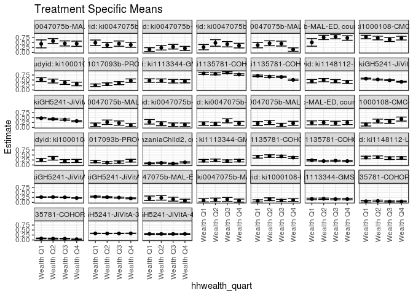

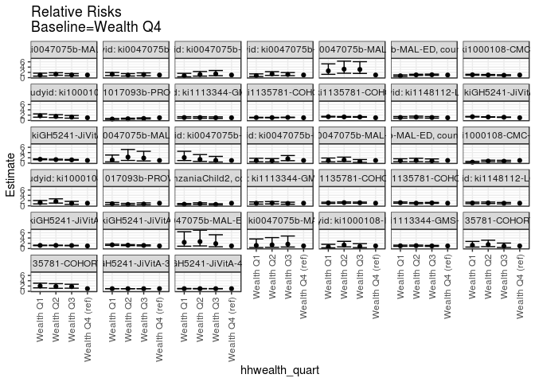

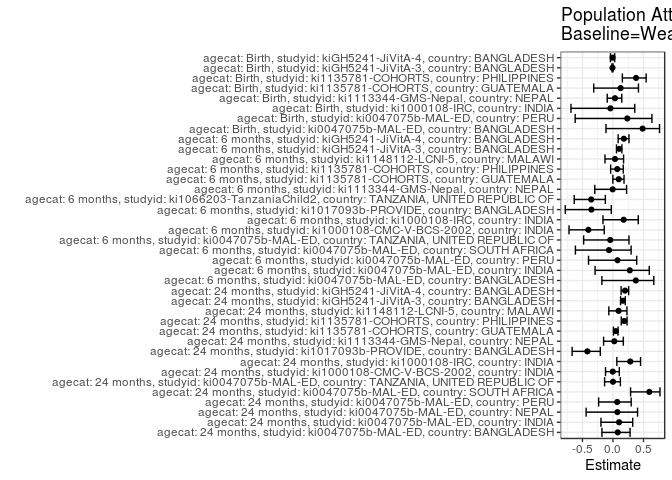

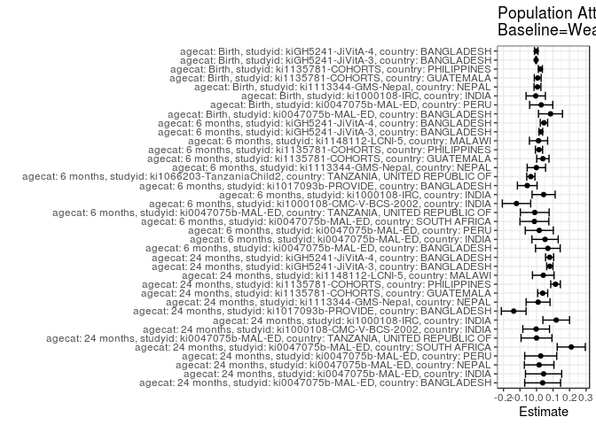

## Results Table

### Parameter: TSM

| agecat | studyid | country | intervention_level | baseline_level | estimate | ci_lower | ci_upper |
| --- | --- | --- | --- | --- | --- | --- | --- |
| Birth | ki0047075b-MAL-ED | BANGLADESH | Wealth Q4 | NA | 0.0892857 | 0.0144243 | 0.1641471 |
| Birth | ki0047075b-MAL-ED | BANGLADESH | Wealth Q1 | NA | 0.2115385 | 0.1002748 | 0.3228021 |
| Birth | ki0047075b-MAL-ED | BANGLADESH | Wealth Q2 | NA | 0.2352941 | 0.1186030 | 0.3519852 |
| Birth | ki0047075b-MAL-ED | BANGLADESH | Wealth Q3 | NA | 0.1666667 | 0.0670328 | 0.2663005 |
| Birth | ki0047075b-MAL-ED | PERU | Wealth Q4 | NA | 0.0925926 | 0.0151013 | 0.1700839 |
| Birth | ki0047075b-MAL-ED | PERU | Wealth Q1 | NA | 0.1090909 | 0.0265080 | 0.1916738 |
| Birth | ki0047075b-MAL-ED | PERU | Wealth Q2 | NA | 0.1296296 | 0.0398314 | 0.2194279 |
| Birth | ki0047075b-MAL-ED | PERU | Wealth Q3 | NA | 0.1538462 | 0.0555522 | 0.2521401 |
| Birth | ki1000108-IRC | INDIA | Wealth Q4 | NA | 0.1208791 | 0.0538154 | 0.1879429 |
| Birth | ki1000108-IRC | INDIA | Wealth Q1 | NA | 0.0816327 | 0.0273532 | 0.1359121 |
| Birth | ki1000108-IRC | INDIA | Wealth Q2 | NA | 0.1616162 | 0.0890131 | 0.2342192 |
| Birth | ki1000108-IRC | INDIA | Wealth Q3 | NA | 0.1000000 | 0.0411252 | 0.1588748 |
| Birth | ki1113344-GMS-Nepal | NEPAL | Wealth Q4 | NA | 0.1696269 | 0.1351006 | 0.2041532 |
| Birth | ki1113344-GMS-Nepal | NEPAL | Wealth Q1 | NA | 0.1757924 | 0.1377835 | 0.2138013 |
| Birth | ki1113344-GMS-Nepal | NEPAL | Wealth Q2 | NA | 0.1853125 | 0.1500579 | 0.2205671 |
| Birth | ki1113344-GMS-Nepal | NEPAL | Wealth Q3 | NA | 0.1685345 | 0.1347513 | 0.2023177 |
| Birth | ki1135781-COHORTS | GUATEMALA | Wealth Q4 | NA | 0.0504237 | 0.0255501 | 0.0752973 |
| Birth | ki1135781-COHORTS | GUATEMALA | Wealth Q1 | NA | 0.0621452 | 0.0244300 | 0.0998604 |
| Birth | ki1135781-COHORTS | GUATEMALA | Wealth Q2 | NA | 0.0767256 | 0.0354014 | 0.1180497 |
| Birth | ki1135781-COHORTS | GUATEMALA | Wealth Q3 | NA | 0.0477100 | 0.0185695 | 0.0768504 |
| Birth | ki1135781-COHORTS | PHILIPPINES | Wealth Q4 | NA | 0.0381224 | 0.0251286 | 0.0511161 |
| Birth | ki1135781-COHORTS | PHILIPPINES | Wealth Q1 | NA | 0.0762127 | 0.0564656 | 0.0959598 |
| Birth | ki1135781-COHORTS | PHILIPPINES | Wealth Q2 | NA | 0.0693308 | 0.0474690 | 0.0911927 |
| Birth | ki1135781-COHORTS | PHILIPPINES | Wealth Q3 | NA | 0.0675629 | 0.0518502 | 0.0832756 |
| Birth | kiGH5241-JiVitA-3 | BANGLADESH | Wealth Q4 | NA | 0.3317948 | 0.3239534 | 0.3396361 |
| Birth | kiGH5241-JiVitA-3 | BANGLADESH | Wealth Q1 | NA | 0.3307678 | 0.3227261 | 0.3388095 |
| Birth | kiGH5241-JiVitA-3 | BANGLADESH | Wealth Q2 | NA | 0.3269764 | 0.3193963 | 0.3345566 |
| Birth | kiGH5241-JiVitA-3 | BANGLADESH | Wealth Q3 | NA | 0.3280047 | 0.3201952 | 0.3358141 |
| Birth | kiGH5241-JiVitA-4 | BANGLADESH | Wealth Q4 | NA | 0.3054539 | 0.2838194 | 0.3270884 |
| Birth | kiGH5241-JiVitA-4 | BANGLADESH | Wealth Q1 | NA | 0.3044719 | 0.2787918 | 0.3301520 |

[output cut: 122 more lines]

### Parameter: E(Y)

| agecat | studyid | country | intervention_level | baseline_level | estimate | ci_lower | ci_upper |
| --- | --- | --- | --- | --- | --- | --- | --- |
| Birth | ki0047075b-MAL-ED | BANGLADESH | NA | NA | 0.1737089 | 0.1227104 | 0.2247075 |
| Birth | ki0047075b-MAL-ED | PERU | NA | NA | 0.1209302 | 0.0772464 | 0.1646140 |
| Birth | ki1000108-IRC | INDIA | NA | NA | 0.1159794 | 0.0840777 | 0.1478811 |
| Birth | ki1113344-GMS-Nepal | NEPAL | NA | NA | 0.1752874 | 0.1470202 | 0.2035545 |
| Birth | ki1135781-COHORTS | GUATEMALA | NA | NA | 0.0575980 | 0.0416028 | 0.0735933 |
| Birth | ki1135781-COHORTS | PHILIPPINES | NA | NA | 0.0613316 | 0.0528136 | 0.0698496 |
| Birth | kiGH5241-JiVitA-3 | BANGLADESH | NA | NA | 0.3290987 | 0.3217223 | 0.3364751 |
| Birth | kiGH5241-JiVitA-4 | BANGLADESH | NA | NA | 0.3035461 | 0.2835868 | 0.3235054 |
| 6 months | ki0047075b-MAL-ED | BANGLADESH | NA | NA | 0.1833333 | 0.1342773 | 0.2323893 |
| 6 months | ki0047075b-MAL-ED | INDIA | NA | NA | 0.1872340 | 0.1372518 | 0.2372162 |
| 6 months | ki0047075b-MAL-ED | PERU | NA | NA | 0.2222222 | 0.1725409 | 0.2719036 |
| 6 months | ki0047075b-MAL-ED | SOUTH AFRICA | NA | NA | 0.1967871 | 0.1473064 | 0.2462679 |
| 6 months | ki0047075b-MAL-ED | TANZANIA, UNITED REPUBLIC OF | NA | NA | 0.2388664 | 0.1855834 | 0.2921494 |
| 6 months | ki1000108-CMC-V-BCS-2002 | INDIA | NA | NA | 0.3008130 | 0.2539566 | 0.3476694 |
| 6 months | ki1000108-IRC | INDIA | NA | NA | 0.2457002 | 0.2038248 | 0.2875757 |
| 6 months | ki1017093b-PROVIDE | BANGLADESH | NA | NA | 0.1589404 | 0.1297581 | 0.1881227 |
| 6 months | ki1066203-TanzaniaChild2 | TANZANIA, UNITED REPUBLIC OF | NA | NA | 0.0965347 | 0.0836528 | 0.1094165 |
| 6 months | ki1113344-GMS-Nepal | NEPAL | NA | NA | 0.2163121 | 0.1823021 | 0.2503220 |
| 6 months | ki1135781-COHORTS | GUATEMALA | NA | NA | 0.4086486 | 0.3769522 | 0.4403450 |
| 6 months | ki1135781-COHORTS | PHILIPPINES | NA | NA | 0.2112260 | 0.1958496 | 0.2266024 |
| 6 months | ki1148112-LCNI-5 | MALAWI | NA | NA | 0.3627451 | 0.3297365 | 0.3957537 |
| 6 months | kiGH5241-JiVitA-3 | BANGLADESH | NA | NA | 0.2513837 | 0.2432545 | 0.2595129 |
| 6 months | kiGH5241-JiVitA-4 | BANGLADESH | NA | NA | 0.2524352 | 0.2383740 | 0.2664965 |
| 24 months | ki0047075b-MAL-ED | BANGLADESH | NA | NA | 0.4764151 | 0.4090254 | 0.5438047 |
| 24 months | ki0047075b-MAL-ED | INDIA | NA | NA | 0.4273128 | 0.3628178 | 0.4918077 |
| 24 months | ki0047075b-MAL-ED | NEPAL | NA | NA | 0.2192982 | 0.1654718 | 0.2731246 |
| 24 months | ki0047075b-MAL-ED | PERU | NA | NA | 0.3681592 | 0.3013164 | 0.4350020 |
| 24 months | ki0047075b-MAL-ED | SOUTH AFRICA | NA | NA | 0.3529412 | 0.2921001 | 0.4137823 |
| 24 months | ki0047075b-MAL-ED | TANZANIA, UNITED REPUBLIC OF | NA | NA | 0.7242991 | 0.6642873 | 0.7843108 |
| 24 months | ki1000108-CMC-V-BCS-2002 | INDIA | NA | NA | 0.7169811 | 0.6710815 | 0.7628807 |
| 24 months | ki1000108-IRC | INDIA | NA | NA | 0.4205379 | 0.3726382 | 0.4684376 |
| 24 months | ki1017093b-PROVIDE | BANGLADESH | NA | NA | 0.3287197 | 0.2903909 | 0.3670485 |
| 24 months | ki1113344-GMS-Nepal | NEPAL | NA | NA | 0.4487705 | 0.4045970 | 0.4929440 |
| 24 months | ki1135781-COHORTS | GUATEMALA | NA | NA | 0.8115942 | 0.7877598 | 0.8354286 |
| 24 months | ki1135781-COHORTS | PHILIPPINES | NA | NA | 0.6229039 | 0.6036892 | 0.6421186 |
| 24 months | ki1148112-LCNI-5 | MALAWI | NA | NA | 0.4425087 | 0.4018409 | 0.4831765 |
| 24 months | kiGH5241-JiVitA-3 | BANGLADESH | NA | NA | 0.4911284 | 0.4780181 | 0.5042387 |
| 24 months | kiGH5241-JiVitA-4 | BANGLADESH | NA | NA | 0.4008848 | 0.3839144 | 0.4178552 |

### Parameter: RR

| agecat | studyid | country | intervention_level | baseline_level | estimate | ci_lower | ci_upper |
| --- | --- | --- | --- | --- | --- | --- | --- |
| Birth | ki0047075b-MAL-ED | BANGLADESH | Wealth Q4 | Wealth Q4 | 1.0000000 | 1.0000000 | 1.0000000 |
| Birth | ki0047075b-MAL-ED | BANGLADESH | Wealth Q1 | Wealth Q4 | 2.3692305 | 0.8805542 | 6.3746820 |
| Birth | ki0047075b-MAL-ED | BANGLADESH | Wealth Q2 | Wealth Q4 | 2.6352938 | 0.9948682 | 6.9805963 |
| Birth | ki0047075b-MAL-ED | BANGLADESH | Wealth Q3 | Wealth Q4 | 1.8666664 | 0.6665867 | 5.2272925 |
| Birth | ki0047075b-MAL-ED | PERU | Wealth Q4 | Wealth Q4 | 1.0000000 | 1.0000000 | 1.0000000 |
| Birth | ki0047075b-MAL-ED | PERU | Wealth Q1 | Wealth Q4 | 1.1781817 | 0.3811695 | 3.6417193 |
| Birth | ki0047075b-MAL-ED | PERU | Wealth Q2 | Wealth Q4 | 1.3999999 | 0.4723963 | 4.1490582 |
| Birth | ki0047075b-MAL-ED | PERU | Wealth Q3 | Wealth Q4 | 1.6615383 | 0.5797459 | 4.7619308 |
| Birth | ki1000108-IRC | INDIA | Wealth Q4 | Wealth Q4 | 1.0000000 | 1.0000000 | 1.0000000 |
| Birth | ki1000108-IRC | INDIA | Wealth Q1 | Wealth Q4 | 0.6753247 | 0.2840672 | 1.6054774 |
| Birth | ki1000108-IRC | INDIA | Wealth Q2 | Wealth Q4 | 1.3370064 | 0.6547919 | 2.7300066 |
| Birth | ki1000108-IRC | INDIA | Wealth Q3 | Wealth Q4 | 0.8272727 | 0.3683993 | 1.8577130 |
| Birth | ki1113344-GMS-Nepal | NEPAL | Wealth Q4 | Wealth Q4 | 1.0000000 | 1.0000000 | 1.0000000 |
| Birth | ki1113344-GMS-Nepal | NEPAL | Wealth Q1 | Wealth Q4 | 1.0363475 | 0.8359501 | 1.2847849 |
| Birth | ki1113344-GMS-Nepal | NEPAL | Wealth Q2 | Wealth Q4 | 1.0924713 | 0.9036999 | 1.3206747 |
| Birth | ki1113344-GMS-Nepal | NEPAL | Wealth Q3 | Wealth Q4 | 0.9935601 | 0.8189419 | 1.2054111 |
| Birth | ki1135781-COHORTS | GUATEMALA | Wealth Q4 | Wealth Q4 | 1.0000000 | 1.0000000 | 1.0000000 |
| Birth | ki1135781-COHORTS | GUATEMALA | Wealth Q1 | Wealth Q4 | 1.2324612 | 0.5632675 | 2.6966948 |
| Birth | ki1135781-COHORTS | GUATEMALA | Wealth Q2 | Wealth Q4 | 1.5216187 | 0.7325077 | 3.1608181 |
| Birth | ki1135781-COHORTS | GUATEMALA | Wealth Q3 | Wealth Q4 | 0.9461825 | 0.4314658 | 2.0749298 |
| Birth | ki1135781-COHORTS | PHILIPPINES | Wealth Q4 | Wealth Q4 | 1.0000000 | 1.0000000 | 1.0000000 |
| Birth | ki1135781-COHORTS | PHILIPPINES | Wealth Q1 | Wealth Q4 | 1.9991597 | 1.3061841 | 3.0597829 |
| Birth | ki1135781-COHORTS | PHILIPPINES | Wealth Q2 | Wealth Q4 | 1.8186401 | 1.1447185 | 2.8893146 |
| Birth | ki1135781-COHORTS | PHILIPPINES | Wealth Q3 | Wealth Q4 | 1.7722637 | 1.1753176 | 2.6723998 |
| Birth | kiGH5241-JiVitA-3 | BANGLADESH | Wealth Q4 | Wealth Q4 | 1.0000000 | 1.0000000 | 1.0000000 |
| Birth | kiGH5241-JiVitA-3 | BANGLADESH | Wealth Q1 | Wealth Q4 | 0.9969048 | 0.9839752 | 1.0100043 |
| Birth | kiGH5241-JiVitA-3 | BANGLADESH | Wealth Q2 | Wealth Q4 | 0.9854781 | 0.9737661 | 0.9973309 |
| Birth | kiGH5241-JiVitA-3 | BANGLADESH | Wealth Q3 | Wealth Q4 | 0.9885770 | 0.9765294 | 1.0007733 |
| Birth | kiGH5241-JiVitA-4 | BANGLADESH | Wealth Q4 | Wealth Q4 | 1.0000000 | 1.0000000 | 1.0000000 |
| Birth | kiGH5241-JiVitA-4 | BANGLADESH | Wealth Q1 | Wealth Q4 | 0.9967851 | 0.9316137 | 1.0665156 |

[output cut: 122 more lines]

### Parameter: PAR

| agecat | studyid | country | intervention_level | baseline_level | estimate | ci_lower | ci_upper |
| --- | --- | --- | --- | --- | --- | --- | --- |
| Birth | ki0047075b-MAL-ED | BANGLADESH | Wealth Q4 | NA | 0.0844232 | 0.0119094 | 0.1569370 |
| Birth | ki0047075b-MAL-ED | PERU | Wealth Q4 | NA | 0.0283376 | -0.0416392 | 0.0983145 |
| Birth | ki1000108-IRC | INDIA | Wealth Q4 | NA | -0.0048997 | -0.0632572 | 0.0534577 |
| Birth | ki1113344-GMS-Nepal | NEPAL | Wealth Q4 | NA | 0.0056605 | -0.0151683 | 0.0264892 |
| Birth | ki1135781-COHORTS | GUATEMALA | Wealth Q4 | NA | 0.0071744 | -0.0134506 | 0.0277994 |
| Birth | ki1135781-COHORTS | PHILIPPINES | Wealth Q4 | NA | 0.0232092 | 0.0110656 | 0.0353529 |
| Birth | kiGH5241-JiVitA-3 | BANGLADESH | Wealth Q4 | NA | -0.0026961 | -0.0054337 | 0.0000416 |
| Birth | kiGH5241-JiVitA-4 | BANGLADESH | Wealth Q4 | NA | -0.0019078 | -0.0124703 | 0.0086547 |
| 6 months | ki0047075b-MAL-ED | BANGLADESH | Wealth Q4 | NA | 0.0685792 | -0.0060197 | 0.1431782 |
| 6 months | ki0047075b-MAL-ED | INDIA | Wealth Q4 | NA | 0.0516408 | -0.0278191 | 0.1311008 |
| 6 months | ki0047075b-MAL-ED | PERU | Wealth Q4 | NA | 0.0165834 | -0.0684414 | 0.1016082 |
| 6 months | ki0047075b-MAL-ED | SOUTH AFRICA | Wealth Q4 | NA | -0.0128903 | -0.1002026 | 0.0744221 |
| 6 months | ki0047075b-MAL-ED | TANZANIA, UNITED REPUBLIC OF | Wealth Q4 | NA | -0.0107967 | -0.0978116 | 0.0762182 |
| 6 months | ki1000108-CMC-V-BCS-2002 | INDIA | Wealth Q4 | NA | -0.1211519 | -0.2069359 | -0.0353679 |
| 6 months | ki1000108-IRC | INDIA | Wealth Q4 | NA | 0.0428531 | -0.0269053 | 0.1126115 |
| 6 months | ki1017093b-PROVIDE | BANGLADESH | Wealth Q4 | NA | -0.0561518 | -0.1157431 | 0.0034396 |
| 6 months | ki1066203-TanzaniaChild2 | TANZANIA, UNITED REPUBLIC OF | Wealth Q4 | NA | -0.0344193 | -0.0592657 | -0.0095729 |
| 6 months | ki1113344-GMS-Nepal | NEPAL | Wealth Q4 | NA | -0.0009643 | -0.0566932 | 0.0547646 |
| 6 months | ki1135781-COHORTS | GUATEMALA | Wealth Q4 | NA | 0.0383703 | 0.0011004 | 0.0756403 |
| 6 months | ki1135781-COHORTS | PHILIPPINES | Wealth Q4 | NA | 0.0149217 | -0.0068942 | 0.0367377 |
| 6 months | ki1148112-LCNI-5 | MALAWI | Wealth Q4 | NA | 0.0120541 | -0.0429426 | 0.0670508 |
| 6 months | kiGH5241-JiVitA-3 | BANGLADESH | Wealth Q4 | NA | 0.0258677 | 0.0146947 | 0.0370408 |
| 6 months | kiGH5241-JiVitA-4 | BANGLADESH | Wealth Q4 | NA | 0.0449886 | 0.0226833 | 0.0672940 |
| 24 months | ki0047075b-MAL-ED | BANGLADESH | Wealth Q4 | NA | 0.0370376 | -0.0714153 | 0.1454906 |
| 24 months | ki0047075b-MAL-ED | INDIA | Wealth Q4 | NA | 0.0426880 | -0.0668757 | 0.1522517 |
| 24 months | ki0047075b-MAL-ED | NEPAL | Wealth Q4 | NA | 0.0159084 | -0.0735859 | 0.1054027 |
| 24 months | ki0047075b-MAL-ED | PERU | Wealth Q4 | NA | 0.0253495 | -0.0715145 | 0.1222134 |
| 24 months | ki0047075b-MAL-ED | SOUTH AFRICA | Wealth Q4 | NA | 0.2100840 | 0.1250543 | 0.2951138 |
| 24 months | ki0047075b-MAL-ED | TANZANIA, UNITED REPUBLIC OF | Wealth Q4 | NA | 0.0000497 | -0.0932838 | 0.0933832 |
| 24 months | ki1000108-CMC-V-BCS-2002 | INDIA | Wealth Q4 | NA | -0.0022713 | -0.0830179 | 0.0784752 |
| 24 months | ki1000108-IRC | INDIA | Wealth Q4 | NA | 0.1192066 | 0.0386256 | 0.1997876 |
| 24 months | ki1017093b-PROVIDE | BANGLADESH | Wealth Q4 | NA | -0.1381065 | -0.2128841 | -0.0633290 |
| 24 months | ki1113344-GMS-Nepal | NEPAL | Wealth Q4 | NA | 0.0095012 | -0.0627695 | 0.0817719 |
| 24 months | ki1135781-COHORTS | GUATEMALA | Wealth Q4 | NA | 0.0372690 | 0.0069764 | 0.0675616 |
| 24 months | ki1135781-COHORTS | PHILIPPINES | Wealth Q4 | NA | 0.1149836 | 0.0858005 | 0.1441666 |
| 24 months | ki1148112-LCNI-5 | MALAWI | Wealth Q4 | NA | 0.0407472 | -0.0245781 | 0.1060725 |
| 24 months | kiGH5241-JiVitA-3 | BANGLADESH | Wealth Q4 | NA | 0.0804312 | 0.0614947 | 0.0993677 |
| 24 months | kiGH5241-JiVitA-4 | BANGLADESH | Wealth Q4 | NA | 0.0791992 | 0.0545512 | 0.1038472 |

### Parameter: PAF

| agecat | studyid | country | intervention_level | baseline_level | estimate | ci_lower | ci_upper |
| --- | --- | --- | --- | --- | --- | --- | --- |
| Birth | ki0047075b-MAL-ED | BANGLADESH | Wealth Q4 | NA | 0.4860038 | -0.1146422 | 0.7629804 |
| Birth | ki0047075b-MAL-ED | PERU | Wealth Q4 | NA | 0.2343304 | -0.6198530 | 0.6380845 |
| Birth | ki1000108-IRC | INDIA | Wealth Q4 | NA | -0.0422466 | -0.6888711 | 0.3568023 |
| Birth | ki1113344-GMS-Nepal | NEPAL | Wealth Q4 | NA | 0.0322924 | -0.0940623 | 0.1440543 |
| Birth | ki1135781-COHORTS | GUATEMALA | Wealth Q4 | NA | 0.1245595 | -0.3154321 | 0.4173808 |
| Birth | ki1135781-COHORTS | PHILIPPINES | Wealth Q4 | NA | 0.3784221 | 0.1536322 | 0.5435093 |
| Birth | kiGH5241-JiVitA-3 | BANGLADESH | Wealth Q4 | NA | -0.0081923 | -0.0165493 | 0.0000960 |
| Birth | kiGH5241-JiVitA-4 | BANGLADESH | Wealth Q4 | NA | -0.0062850 | -0.0417357 | 0.0279592 |
| 6 months | ki0047075b-MAL-ED | BANGLADESH | Wealth Q4 | NA | 0.3740686 | -0.1820668 | 0.6685550 |
| 6 months | ki0047075b-MAL-ED | INDIA | Wealth Q4 | NA | 0.2758089 | -0.2935764 | 0.5945715 |
| 6 months | ki0047075b-MAL-ED | PERU | Wealth Q4 | NA | 0.0746253 | -0.4008552 | 0.3887175 |
| 6 months | ki0047075b-MAL-ED | SOUTH AFRICA | Wealth Q4 | NA | -0.0655036 | -0.6156269 | 0.2973019 |
| 6 months | ki0047075b-MAL-ED | TANZANIA, UNITED REPUBLIC OF | Wealth Q4 | NA | -0.0451996 | -0.4806415 | 0.2621831 |
| 6 months | ki1000108-CMC-V-BCS-2002 | INDIA | Wealth Q4 | NA | -0.4027483 | -0.7205214 | -0.1436666 |
| 6 months | ki1000108-IRC | INDIA | Wealth Q4 | NA | 0.1744119 | -0.1641024 | 0.4144882 |
| 6 months | ki1017093b-PROVIDE | BANGLADESH | Wealth Q4 | NA | -0.3532882 | -0.7818656 | -0.0277929 |
| 6 months | ki1066203-TanzaniaChild2 | TANZANIA, UNITED REPUBLIC OF | Wealth Q4 | NA | -0.3565489 | -0.6353329 | -0.1252907 |
| 6 months | ki1113344-GMS-Nepal | NEPAL | Wealth Q4 | NA | -0.0044579 | -0.2981335 | 0.2227797 |
| 6 months | ki1135781-COHORTS | GUATEMALA | Wealth Q4 | NA | 0.0938957 | -0.0022458 | 0.1808147 |
| 6 months | ki1135781-COHORTS | PHILIPPINES | Wealth Q4 | NA | 0.0706434 | -0.0382218 | 0.1680933 |
| 6 months | ki1148112-LCNI-5 | MALAWI | Wealth Q4 | NA | 0.0332302 | -0.1309467 | 0.1735740 |
| 6 months | kiGH5241-JiVitA-3 | BANGLADESH | Wealth Q4 | NA | 0.1029013 | 0.0572784 | 0.1463163 |
| 6 months | kiGH5241-JiVitA-4 | BANGLADESH | Wealth Q4 | NA | 0.1782184 | 0.0846723 | 0.2622042 |
| 24 months | ki0047075b-MAL-ED | BANGLADESH | Wealth Q4 | NA | 0.0777424 | -0.1810786 | 0.2798454 |
| 24 months | ki0047075b-MAL-ED | INDIA | Wealth Q4 | NA | 0.0998987 | -0.1972267 | 0.3232842 |
| 24 months | ki0047075b-MAL-ED | NEPAL | Wealth Q4 | NA | 0.0725424 | -0.4398007 | 0.4025717 |
| 24 months | ki0047075b-MAL-ED | PERU | Wealth Q4 | NA | 0.0688547 | -0.2352064 | 0.2980674 |
| 24 months | ki0047075b-MAL-ED | SOUTH AFRICA | Wealth Q4 | NA | 0.5952381 | 0.2883722 | 0.7697783 |
| 24 months | ki0047075b-MAL-ED | TANZANIA, UNITED REPUBLIC OF | Wealth Q4 | NA | 0.0000686 | -0.1374634 | 0.1209715 |
| 24 months | ki1000108-CMC-V-BCS-2002 | INDIA | Wealth Q4 | NA | -0.0031679 | -0.1223520 | 0.1033598 |
| 24 months | ki1000108-IRC | INDIA | Wealth Q4 | NA | 0.2834622 | 0.0632838 | 0.4518869 |
| 24 months | ki1017093b-PROVIDE | BANGLADESH | Wealth Q4 | NA | -0.4201346 | -0.6694879 | -0.2080245 |
| 24 months | ki1113344-GMS-Nepal | NEPAL | Wealth Q4 | NA | 0.0211717 | -0.1538561 | 0.1696496 |
| 24 months | ki1135781-COHORTS | GUATEMALA | Wealth Q4 | NA | 0.0459207 | 0.0076587 | 0.0827074 |
| 24 months | ki1135781-COHORTS | PHILIPPINES | Wealth Q4 | NA | 0.1845928 | 0.1358367 | 0.2305981 |
| 24 months | ki1148112-LCNI-5 | MALAWI | Wealth Q4 | NA | 0.0920822 | -0.0683652 | 0.2284336 |
| 24 months | kiGH5241-JiVitA-3 | BANGLADESH | Wealth Q4 | NA | 0.1637682 | 0.1240759 | 0.2016618 |
| 24 months | kiGH5241-JiVitA-4 | BANGLADESH | Wealth Q4 | NA | 0.1975610 | 0.1333029 | 0.2570549 |